# PSTAT 131 Final Project- Ankita Pattnaik

# Spotify Personal Data Analysis

## Introduction

For my project I decided to analyze my Spotify data. The dataset provided to me was a personalized data set given to my by Spotify after requesting it through my Settings" on the web platform.

Spotify is a major music streaming site which is used every day by millions. With a student plan, you pay $5.99 a month to get unlimited streams, personally curated playlists, and even a subscription to Hulu! You can’t miss out.

I decided to analyze my Spotify data because I don’t listen to music often. Every year Spotify provides an end of the year playlist and runs you through a personally curated “Spotify Wrapped” which shows you your most streamed and top artists. I wanted to see for myself how accurate this wrapped data was so I was interested to look into it myself.

For context these were the variables I worked with, which can also be elaborated on in the codebook: - `end_time`: The data and exact time (down to the second) the song was streamed. This variable contains observations provided by Spotify. I later remove this variable. - `artist_name`: The name of the artist, to the song streamed. This variable contains observations provided by Spotify. - `track_name`: The title of the track streamed. This variable contains observations provided by Spotify. - `date`: The date at which the song was streamed. This variable contains observations provided by Spotify. - `seconds`: How many seconds I streamed the song for. This is a variable I created with the provided variable `ms_played`. - `minutes`: How many minutes I streamed the song for. This is a variable I also created with the previously created `minutes` variable. - `skipped`: Whether or not I skipped or streamed the song depending on it’s playtime. If the song streamed for less than one minute and thirty seconds, I assume I skipped. If the song streamed for more than one minute and thirty seconds, I assume I streamed. This is also a variable I created based on the previously created `minutes` variable.

# Loading Packages

- First I downloaded the necessary packages, which were A LOT.

```r
library(rjson)
library(readr)
library(DBI)
library(viridis)
library(lubridate)
library(tidyverse)
```

```r
library(ggplot2)
library(spotifyr)
library(plotly)
library(knitr)
library("gghighlight")
library(jsonlite)
library(dbplyr)
library(tidymodels)
library(ISLR)
library(ISLR2)
library(discrim)
library(poissonreg)
library(corrr)
library(corrplot)
library(klaR)
library(pROC)
library(glmnet)
library(dplyr)
library(janitor)
library(rpart)
library(rpart.plot)
library(ranger)
library(vip)
library(RJSONIO)
library(rjson)
tidymodels_prefer()
library(randomForest)
library(xgboost)
```

# Data

There were a lot of files provided to me through the zip provided (such as payment history, playlists, family plans, personal information) and I thought it would be best to work with the `StreamingHistory0.json` file, as it tracked every song I streamed, the artist, the milliseconds I streamed it, the date I streamed it.

- I downloaded the JSON data provided to me into R. At first it was difficult to work with because it downloaded as a list.

```r
#download streaming history from date
streaming_hist_0<-RJSONIO::fromJSON("/Users/ankitapattnaik/Downloads/MyData/StreamingHistory0.json", flatten=TRUE)
```

I then transformed the list into a dataframe using `sapply()` and turned my respective data to a data frame with 4 variables and 6,672 observations.

```r
#turn list into dataframe
streaming_hist<-data.frame(t(sapply(streaming_hist_0,c)))

#check that the new created variable is a data.frame. it is. also check column name to see that the data frame categorized accordingly.
class(streaming_hist)
```

```
## [1] "data.frame"
```

```r
colnames(streaming_hist) #check that the variables are in their respective columns
```

```
## [1] "endTime"    "artistName" "trackName"  "msPlayed"
```

# Variable Transformation

Interpreting the `msPlayed`, or milliseconds played variable, was a little difficult so I transformed that data into seconds and minutes. I also took the `endTime` column and extracted the date to make a new variable with just data in the format of yyyy-mm-dd. That way my data would be easier to inetrpret.

I additionally created a `skipped` variable which determined whether or not I skipped the data based off the now minutes played. If I listened to the song for less than a minute and a half, I assumed I skipped the song and if it was more than one minute and thirty seconds, I assumed I streamed it. I based this off the google result for the timing of an average song which is: three minutes and thirty seconds.

I then called `clean_names()` function to the data to make the variable names easier to work with and unlisted the variables into characters, as the observations of each data set seemed to have stored into my data frame as lists.

```r
spotify <- streaming_hist %>%
  as_tibble() %>%
  mutate_at("endTime", ymd_hm) %>%
  mutate(endTime = endTime - hours(6)) %>%
  mutate(date = floor_date(endTime, "day") %>% as_date, seconds = as.numeric(msPlayed) / 1000, minutes = seconds / 60) %>%
  mutate(skipped= case_when(
    minutes > 1.5 ~ "streamed",
    minutes < 1.5 ~ "skipped"
  )) %>%
  mutate(skipped = factor(skipped, levels = c("skipped", "streamed")))

spotify<-clean_names(spotify)

#turn remainder of the of the listed variables into characters
spotify$artist_name<-unlist(spotify$artist_name)
spotify$track_name<-unlist(spotify$track_name)
spotify$ms_played<-unlist(spotify$ms_played)
```

# EDA: Exploratory Data Analysis

I had a lot of fun making these graphs. I found an online source that guided me through seeing how I could manipulate my variables to display specifically Spotify data and I had a lot of fun playing around seeing my streaming history.

- First I took a look at my playback activity week by week. I calculated the average hours of music through the information given to my in my `minutes` category. I then took my date and grouped it by week.

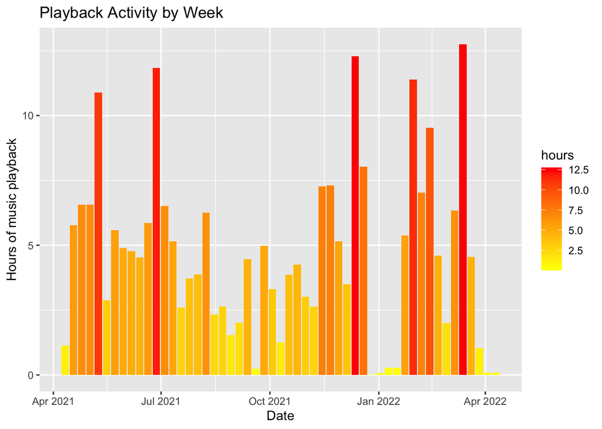

```r
#playback activity
streamingHours <- spotify %>%
  filter(date >= "2020-01-01") %>%
  group_by(date) %>%
  group_by(date = floor_date(date, "week")) %>%
  summarize(hours = sum(minutes) / 60) %>%
  arrange(date) %>%
  ggplot(aes(x = date, y = hours)) +
  geom_col(aes(fill = hours)) +
  scale_fill_gradient(low = "yellow", high = "red") +
  labs(x= "Date", y= "Hours of music playback") +
  ggtitle("Playback Activity by Week")
streamingHours
```

```r
#playback activity by artist
hoursArtist <- spotify %>%
  group_by(artist_name, date = floor_date(date, "month")) %>%
  summarize(hours = sum(minutes) / 60) %>%
  ggplot(aes(x = date, y = hours, group = artist_name)) +
  labs(x= "Date", y= "Hours of Music") +
  ggtitle("Most Listened to Artists", "My top 3: DAY6, NCT DREAM, and SEVENTEEN") +
  geom_line() +
  gghighlight(artist_name == "DAY6" || artist_name == "NCT DREAM" || artist_name == "SEVENTEEN")
```

```
## label_key: artist_name
```

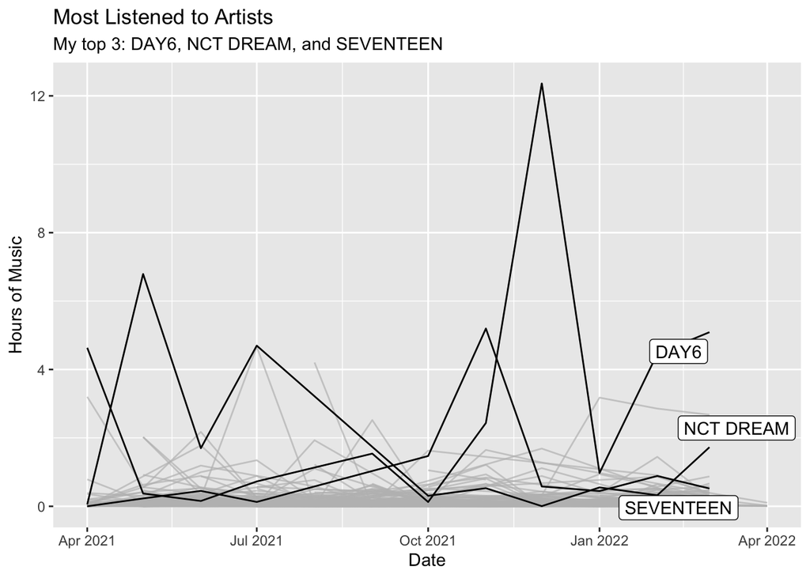

```r
hoursArtist
```

Towards the end of last year I was really feeling Day6, clearly.

- I then focused on the `track_name` to see which tracks I listened to the most. I created a new variable `top10_track` and counted how many times I had streamed each song. I then took the top10 and worked with that to determine which 10 songs I listened to the most, and how many times I streamed it.

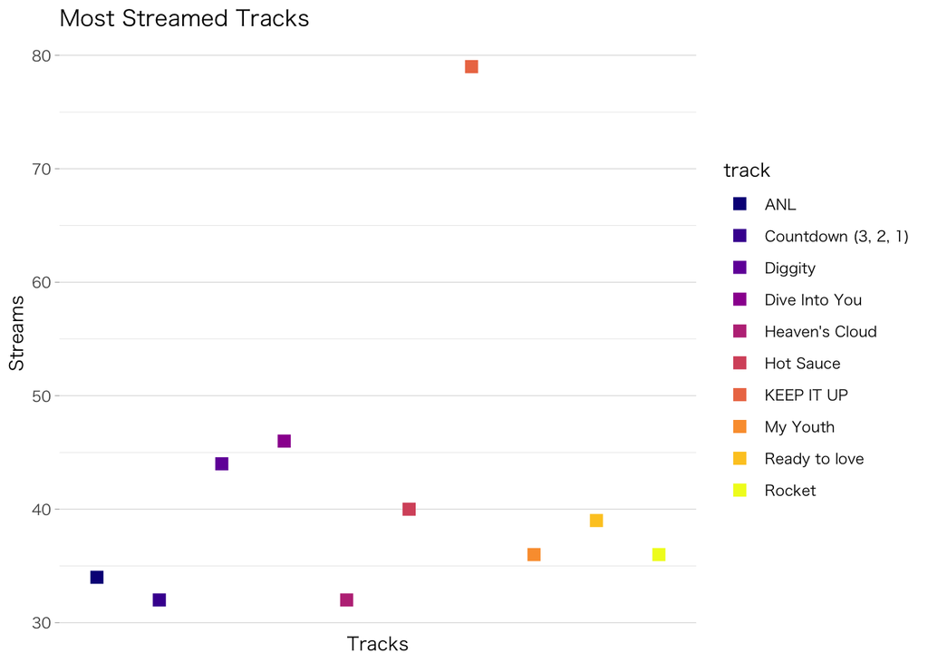

```r
#top 10 most streamed tracks graph
top10_track<-spotify %>%
  count(spotify$track_name) %>%
  arrange(-n)%>%
  head(.,10)
names(top10_track)<-c('track', 'counter')

# Listened time vs. number of songs
listenedTimes_songs <- top10_track %>%
  group_by(track) %>%
  mutate(track = iconv(track, to = "UTF-8")) %>%
  summarize(timesStreamed = sum(counter), total_songs= n_distinct(timesStreamed)) %>%
  arrange(desc(timesStreamed)) %>%
  slice(1:10) %>%
  ggplot(aes(x=track , y = timesStreamed,color = track)) +
  geom_point(size = 3, shape = 15) +
  scale_color_viridis(discrete = TRUE, option="C") +
  theme_light(base_size=10, base_family="HiraKakuProN-W3") +
  theme (
    axis.text.x = element_blank(),
    panel.grid.major.x = element_blank(),
    panel.border = element_blank(),
    axis.ticks.x = element_blank(),
  ) +
  labs(title = "Most Streamed Tracks ") +
  xlab("Tracks")+
  ylab("Streams")
listenedTimes_songs
```

This was fun to see because it seems like 7 of the 10 sings i listened to are from the same album of the group I mentioned, NCT DREAM. “KEEP IT UP” is a song that really resonated with me when it came out so I listened to it on repeat, hence the 79 streams.

```r
#how many hours of kpop, by genre
top10_artist<-spotify %>%
  count(spotify$artist_name) %>%
  arrange(-n)%>%
  head(.,10)
names(top10_artist)<-c('artist name', 'count')
top10_artist
```

```
## # A tibble: 10 × 2
##    `artist name`       count
##    <chr>               <int>
##  1 DAY6                  766
##  2 NCT DREAM             442
##  3 SEVENTEEN             258
##  4 Rex Orange County     224
##  5 BTS                   177
##  6 HONNE                 175
##  7 DAY6 (Even of Day)    145
##  8 Sam Kim               128
##  9 Ravi Shankar          126
## 10 TOMORROW X TOGETHER   118
```

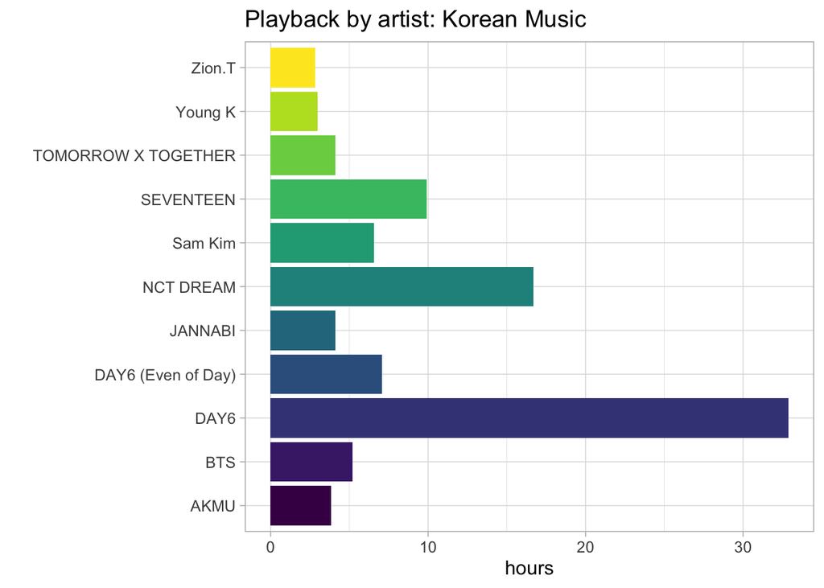

```r
k_music <- spotify %>%
  group_by(artist_name, date = floor_date(date, "hour")) %>%
  mutate(artist_name = iconv(artist_name, to = "UTF-8")) %>%
  filter(artist_name == "DAY6" ||
         artist_name == "NCT DREAM" ||
         artist_name == "SEVENTEEN" ||
         artist_name == "BTS" ||
         artist_name == "DAY6 (Even of Day)" ||
         artist_name == "Sam Kim" ||
         artist_name == "TOMORROW X TOGETHER" ||
         artist_name == "JANNABI" ||
         artist_name == "AKMU" ||
         artist_name == "Young K" ||
         artist_name == "Zion.T") %>%
  summarize(hours = sum(minutes)/60) %>%
  ggplot(aes(x= artist_name, y = hours)) +
  geom_col(aes(fill = artist_name))+
  scale_fill_viridis(discrete = TRUE,guide = FALSE, option="D") +
  labs(title = "Playback by artist: Korean Music") +
  theme_light(base_size=12) +
  xlab("") +
  coord_flip()
k_music
```

As mentioned before, in the time span of April 2021 to April 2022, I listened to a lot of DAY6.

```r
#listening to spotify throughout the week
dayHour <- spotify %>%
  group_by(date, hour = hour(end_time), weekday = wday(date, label = TRUE)) %>%
  summarize(hoursListened = sum(minutes)/60)
```

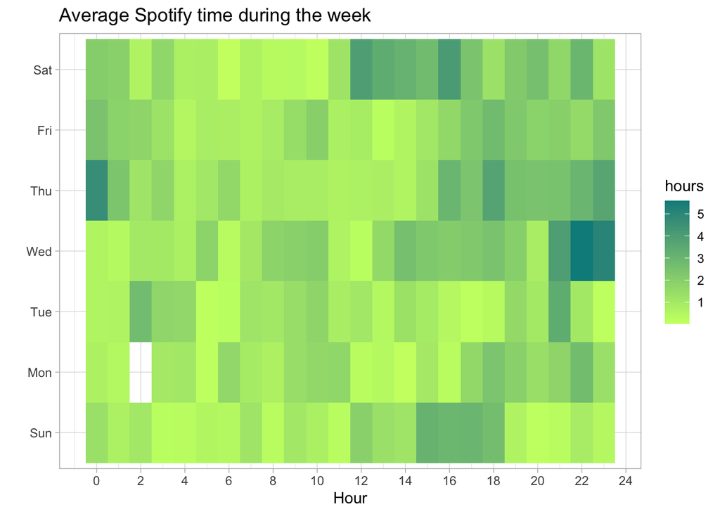

```r
dayHour %>%
  group_by(weekday, hour) %>%
  summarize(hours = sum(hoursListened)) %>%
  ggplot(aes(x= hour, y= weekday, fill= hours)) +
  geom_tile() +
  scale_x_continuous(breaks= seq(0, 24, 2)) +
  scale_fill_gradient(low= "darkolivegreen1", high= "cyan4") +
  labs(title= "Average Spotify time during the week",
       x= "Hour", y= "") +
  theme_light()
```